# Actividad 3: Modelización predictiva

Jorge Solán Morote

2025-05-16

Para la elaboración de esta actividad serán necesarias las siguientes librerías

```r
library(ggplot2)
library(caTools)
library(dplyr)
library(car)
library(pROC)
library(nnet)
```

## 1 Regresión lineal

```r
# Tuve un problema de caracteres en los vecindarios y puse ese encoding de fichero
# https://forum.posit.co/t/how-to-handle-sepcial-characters-in-r/135311
data <- read.csv("Barcelona_Rent_Price_vf.csv", stringsAsFactors = TRUE, fileEncoding = "latin1")
str(data)
```

```
## 'data.frame':    7949 obs. of  8 variables:
##  $ price        : int  3000 1250 2200 3468 1100 2500 1500 2057 1800 1800 ...
##  $ rooms        : int  3 1 4 3 1 3 2 1 3 1 ...
##  $ bathroom     : int  2 1 2 2 1 2 2 1 2 1 ...
##  $ lift         : logi  FALSE FALSE FALSE FALSE TRUE TRUE ...
##  $ terrace      : logi  FALSE FALSE FALSE FALSE FALSE FALSE ...
##  $ square_meters: int  150 35 90 98 45 180 60 74 100 90 ...
##  $ real_state   : Factor w/ 4 levels "apartment","attic",..: 1 1 1 1 1 1 1 1 1 1 ...
##  $ neighborhood : Factor w/ 10 levels "Ciutat Vella",..: 2 2 3 1 5 2 2 8 1 3 ...
```

#### 1.1 Estudio de correlación lineal

Nos piden crear la matriz de relación entre las variables numéricas y presentarlas en una tabla de mayor a menor.

```r
# Seleccionar solo columnas numéricas (int y numeric)
numeric_vars <- data[, sapply(data, is.numeric)]

# Matriz de correlación
cor_matrix <- cor(numeric_vars)

# Mostrar la matriz
print(cor_matrix)
```

```
##                   price     rooms  bathroom square_meters
## price         1.0000000 0.3433956 0.5788707     0.6927869
## rooms         0.3433956 1.0000000 0.5741637     0.6467779
## bathroom      0.5788707 0.5741637 1.0000000     0.7559238
## square_meters 0.6927869 0.6467779 0.7559238     1.0000000
```

```r
#Convertimos la matriz de correlacion a una tabla para manipularla mejor
cor_pairs <- as.data.frame(as.table(cor_matrix))
head(cor_pairs)
```

```
##            Var1  Var2      Freq
## 1         price price 1.0000000
## 2         rooms price 0.3433956
## 3      bathroom price 0.5788707
## 4 square_meters price 0.6927869
## 5         price rooms 0.3433956
## 6         rooms rooms 1.0000000
```

```r
# Eliminamos la diagonal
cor_pairs <- cor_pairs[cor_pairs$Var1 != cor_pairs$Var2, ]
#Eliminamos los duplicados (mitad superior y mitad inferior)
cor_pairs <- cor_pairs[!duplicated(cor_pairs[,3]), ]
# Ordenamos
cor_pairs <- cor_pairs[order(-abs(cor_pairs$Freq)), ]

print(cor_pairs)
```

```
##             Var1     Var2      Freq
## 12 square_meters bathroom 0.7559238
## 4  square_meters    price 0.6927869
## 8  square_meters    rooms 0.6467779
## 3       bathroom    price 0.5788707
## 7       bathroom    rooms 0.5741637
## 2          rooms    price 0.3433956
```

La matriz de correlación nos dice cuan relacionado están dos variables, si una aumenta, cuanto lo hace la otra, o cuanto disminuye. Viendo la tabla creada podemos darnos cuenta de estas relaciones.

Lo primero que vemos es la relación que tienen los metros cuadrados con el resto, cosa que tiene sentido, a más metros cuadrado más espacio hay para baños y habitaciones y al ser más grande es lógico también que el precio aumente. Lo más destacable de la tabla es quizas la poca relación que hay entre el número de habitaciones y el precio siendo la que menos.

#### 1.2 Estudio comparativo entre barrios de Barcelona

Para observar los distintos tipos de vivinedas en los barrios de Barcelona según el precio lo más conveniente es un boxplot que nos muestre cómo se distribuye el precio en cada uno.

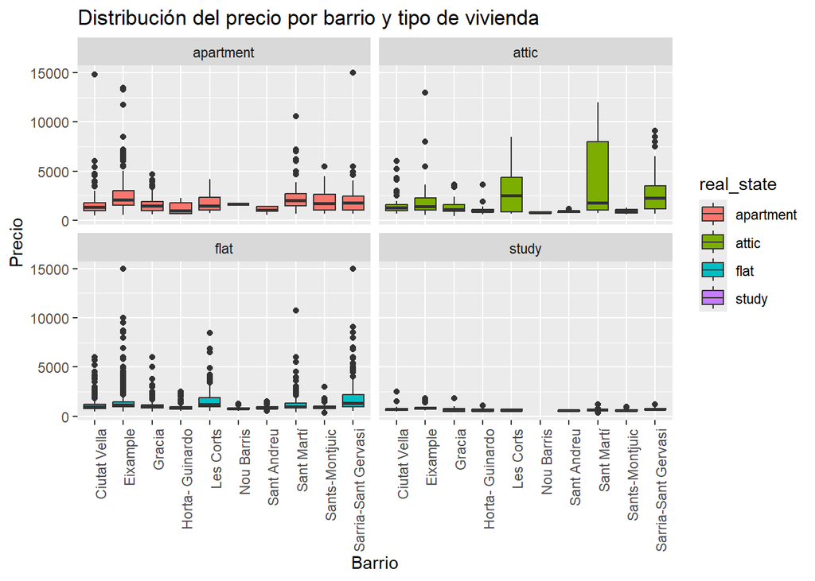

```r
# Boxplot del precio por barrio y tipo de vivienda
ggplot(data, aes(x = neighborhood, y = price, fill = real_state)) +
  geom_boxplot() +
  facet_wrap(~real_state) +
  theme(axis.text.x = element_text(angle = 90, hjust = 1)) +
  labs(title = "Distribución del precio por barrio y tipo de vivienda", y = "Precio", x = "Barrio")
```

Según las tablas podemos ver varios patrones y casos. En las vivinedas de tipo estudio es donde menos varía el precio, manteniendose precios bajos. Los pisos tipo flat y apartamentos es donde mayor variación y espúreos hay, sobre todo en los barrios de Ciutat Vella, Eixample, Sant Martí y Sarria-Santi.  
Por último, en los áticos, a simple vista, es donde, parece, mayor precio medio hay por vivienda.

Para ver mejor los precios medios y los precios más repetidos podemos crear una tabla de medias y medianas por barrio y vivienda.

```r
summary_table <- data %>%
  group_by(real_state, neighborhood) %>%
  summarise(
    precio_medio = mean(price),
    precio_mediana = median(price),
    count = n(),
    .groups = 'drop'
  ) %>%
  arrange(desc(precio_medio))

#print(summary_table) # Ver todos
head(summary_table)
```

```
## # A tibble: 6 × 5
##   real_state neighborhood        precio_medio precio_mediana count
##   <fct>      <fct>                      <dbl>          <dbl> <int>
## 1 attic      Sant Martí                 4052.           1800    19
## 2 attic      Les Corts                  2950.           2500    20
## 3 attic      Sarria-Sant Gervasi        2789.           2300    74
## 4 apartment  Sant Martí                 2552.           2057    53
## 5 apartment  Eixample                   2478.           2062   380
## 6 apartment  Sarria-Sant Gervasi        2230.           1775   116
```

#### 1.3 Generación de los conjuntos de entrenamiento y de test

Dividimos los datos en datos de test y entrenamiento en relación 20-80 respectivamente

```r
# Semilla aleatoria
set.seed(3461)

# Dividir los datos en subconjuntos
# https://r-coder.com/subset-en-r/
split <- sample.split(data$price, SplitRatio = 0.8)
training <- subset(data, split == TRUE)
testing <- subset(data, split == FALSE)
```

#### 1.4 Estimación del modelo de regresión lineal con predictores cuantitativos

Una vez divididos ya podemos entrenar el modelo. Primero se nos pide estimar por mínimos cuadrado un modelo de regresión lineal respecto a precios. El modelo a crear tiene la siguiente forma:
$$\hat{y} = \hat{\beta}_0 + \hat{\beta}_1 x_1 + \hat{\beta}_2 x_2 + \cdots
+ \hat{\beta}_k x_k$$

Siendo
$$\hat{\beta}$$
el vector de los estimadores mínimos cuadráticos de los parámetros.

$$x$$
el vector de los parámetros.

$$\hat{y}$$
el vector predicho.

Para calcular el vector de los estimadores debemos resolver la siguiente ecuación. El desarrollo de porqué está explicado en los apuntes de la asignatura.

$$\hat{\boldsymbol{\beta}} = \left( X^T X
\right)^{-1} X^T \mathbf{y}$$

```r
# matriz de variables explicativas
X <- model.matrix(~ rooms + bathroom + square_meters, data = training)

# Vector de respuesta
y <- training$price

# Calculo de beta
beta <- solve(t(X) %*% X) %*% t(X) %*% y
```

Para ver los valores que toma beta relacionado con sus parámetros correpondientes podemos hacer la siguiente tabla.

```r
# Mostrar los coeficientes
coeficientes <- as.vector(beta)
nombres <- colnames(X)
resultado <- data.frame(Variable = nombres, Coeficiente = coeficientes)
print(resultado)
```

```
##        Variable Coeficiente
## 1   (Intercept)   155.49170
## 2         rooms  -203.36183
## 3      bathroom   284.32937
## 4 square_meters    16.14615
```

Al buscar documentación sobre la regresión lineal me he encontrado con lafunción de R **lm** que realiza lo mismo de una manera muy parecida ya que es igual que crear la matriz **X** añadiendo en la función la variable a predecir y además te muestra otras métricas importantes.  
Además así podemos corroborar de que hemos hecho bien nuestro modelo.

```r
# https://www.rdocumentation.org/packages/stats/versions/3.6.2/topics/lm
model <- lm(price ~ rooms + bathroom + square_meters, data = training)

# Ver el resumen del modelo
summary(model)
```

```
##
## Call:
## lm(formula = price ~ rooms + bathroom + square_meters, data = training)
##
## Residuals:
##     Min      1Q  Median      3Q     Max
## -3544.3  -321.8  -124.5    98.4 13271.8
##
## Coefficients:
##                Estimate Std. Error t value Pr(>|t|)
## (Intercept)    155.4917    26.4865   5.871 4.56e-09 ***
## rooms         -203.3618    12.0124 -16.929  < 2e-16 ***
## bathroom       284.3294    21.6205  13.151  < 2e-16 ***
## square_meters   16.1462     0.3554  45.427  < 2e-16 ***
## ---
## Signif. codes:  0 '***' 0.001 '**' 0.01 '*' 0.05 '.' 0.1 ' ' 1
##
## Residual standard error: 817.2 on 6476 degrees of freedom
## Multiple R-squared:  0.4916, Adjusted R-squared:  0.4914
## F-statistic:  2087 on 3 and 6476 DF,  p-value: < 2.2e-16
```

#### 1.4.1 Comprobación de colinealidad

Para comprobar la colinealidad del modelo o no una buena práctica es mirar la matriz de correlación entre variables. En ella podemos ver que la variable de rooms es la menos relacionada con el precio y mantiene una relación adecuada con las otras dos. Además en nuestro modelo, cuanto más crece el número de habitaciones más disminuye el precio, cosa que aparentemente no tiene sentido con lo que podemos pensar que no es tan importante en el modelo.

Para probarlo podemos repetir el cálculo del modelo sin este vector y comparar modelos, ya que si estos son muy parecidos entre sí nos confirma la teoría

```r
model_2 <- lm(price ~ square_meters + bathroom, data = training)

summary(model_2)
```

```
##
## Call:
## lm(formula = price ~ square_meters + bathroom, data = training)
##
## Residuals:
##     Min      1Q  Median      3Q     Max
## -3098.8  -353.9  -128.7   117.4 13523.9
##
## Coefficients:
##               Estimate Std. Error t value Pr(>|t|)
## (Intercept)   -48.0250    24.1160  -1.991   0.0465 *
## square_meters  13.7391     0.3329  41.276   <2e-16 ***
## bathroom      224.9478    21.7994  10.319   <2e-16 ***
## ---
## Signif. codes:  0 '***' 0.001 '**' 0.01 '*' 0.05 '.' 0.1 ' ' 1
##
## Residual standard error: 835 on 6477 degrees of freedom
## Multiple R-squared:  0.4691, Adjusted R-squared:  0.4689
## F-statistic:  2861 on 2 and 6477 DF,  p-value: < 2.2e-16
```

Como podemos ver ambos valores de los estimadores de bathroom y square_meters han variado relativamente poco con respecto al modelo inicial y se ha mantenido un p-valor por debajo de un umbral
$$\alpha < 0.05$$
en el ambos estimadores por lo que podemos decir que la variable rooms no era tan importante para el modelo y podemos excluirla.

#### 1.5 Estimación del modelo de regresión lineal con predictores cuantitativos y cualitativos

Ahora, nos piden hacer el modelo con todas las variables, aunque en el factor de vecindario coger como referencia el barrio Sarria-Sant Gervasi, esto lo que hará es que, cuando todas las demás variables sean 0, el barrio sí que se tomará el referenciado.

```r
training$neighborhood <- relevel(as.factor(training$neighborhood), ref = "Sarria-Sant Gervasi")

modelo_completo <- lm(price ~ rooms + bathroom + square_meters +
                      lift + terrace + real_state +
                      neighborhood,
                      data = training)
summary(modelo_completo)
```

```
##
## Call:
## lm(formula = price ~ rooms + bathroom + square_meters + lift +
##     terrace + real_state + neighborhood, data = training)
##
## Residuals:
##     Min      1Q  Median      3Q     Max
## -3465.2  -303.8   -42.6   168.8 12784.4
##
## Coefficients:
##                              Estimate Std. Error t value Pr(>|t|)
## (Intercept)                  903.5736    43.7578  20.649  < 2e-16 ***
## rooms                       -147.3394    11.6774 -12.617  < 2e-16 ***
## bathroom                     254.5423    20.1551  12.629  < 2e-16 ***
## square_meters                 15.8747     0.3356  47.304  < 2e-16 ***
## liftTRUE                    -157.6869    22.4841  -7.013 2.56e-12 ***
## terraceTRUE                   48.5188    24.7198   1.963  0.04972 *
## real_stateattic             -402.4805    55.5512  -7.245 4.82e-13 ***
## real_stateflat              -829.9370    29.4408 -28.190  < 2e-16 ***
## real_statestudy             -838.9675    82.6674 -10.149  < 2e-16 ***
## neighborhoodCiutat Vella    -107.4935    34.5284  -3.113  0.00186 **
## neighborhoodEixample          74.9836    29.1910   2.569  0.01023 *
## neighborhoodGracia           -53.3539    40.9043  -1.304  0.19216
## neighborhoodHorta- Guinardo -212.3433    53.3398  -3.981 6.94e-05 ***
## neighborhoodLes Corts       -121.5010    43.3484  -2.803  0.00508 **
## neighborhoodNou Barris      -178.8040    85.7990  -2.084  0.03720 *
## neighborhoodSant Andreu     -165.6241    69.9405  -2.368  0.01791 *
## neighborhoodSant Martí       167.9355    41.4035   4.056 5.05e-05 ***
## neighborhoodSants-Montjuic   -87.3459    43.1889  -2.022  0.04317 *
## ---
## Signif. codes:  0 '***' 0.001 '**' 0.01 '*' 0.05 '.' 0.1 ' ' 1
##
## Residual standard error: 751.5 on 6462 degrees of freedom
## Multiple R-squared:  0.571,  Adjusted R-squared:  0.5698
## F-statistic: 505.9 on 17 and 6462 DF,  p-value: < 2.2e-16
```

Una vez creado hace falta decidir las variables explicativas. Podemos observar algunos detalles, primero es lo mismo mensacionado en el apartado anterior de la linealidad negativa de rooms lo que puede ser extraño, aumenta el número de habitaciones y disminuye el precio. Otra cosa son los p-valores de algunos barrios y de si tiene o no terraza, que son algo elevados y nos pueden decir que no son tan explicativos para el modelo.

Otra herramientas que nos dicen en el enunciado es el FIV, Factor de Inflación de la Varianza o VIR por sus siglas en inglés.

```r
#https://www.rdocumentation.org/packages/car/versions/3.1-3/topics/vif
vif(modelo_completo)
```

```
##                   GVIF Df GVIF^(1/(2*Df))
## rooms         1.966969  1        1.402487
## bathroom      2.461233  1        1.568832
## square_meters 2.926612  1        1.710734
## lift          1.244870  1        1.115738
## terrace       1.148809  1        1.071825
## real_state    1.283787  3        1.042515
## neighborhood  1.331282  9        1.016024
```

Ya que los valores observadores son < 4, de este modo no podemos decir si alguna da problemas de colinealidad.

```r
modelo_nTr <- lm(price ~ rooms + bathroom + square_meters +
                      lift + real_state + neighborhood,
                      data = training)
summary(modelo_nTr)
```

```
##
## Call:
## lm(formula = price ~ rooms + bathroom + square_meters + lift +
##     real_state + neighborhood, data = training)
##
## Residuals:
##     Min      1Q  Median      3Q     Max
## -3485.3  -306.3   -44.3   169.0 12775.2
##
## Coefficients:
##                              Estimate Std. Error t value Pr(>|t|)
## (Intercept)                  900.0149    43.7299  20.581  < 2e-16 ***
## rooms                       -147.5725    11.6794 -12.635  < 2e-16 ***
## bathroom                     255.1740    20.1570  12.659  < 2e-16 ***
## square_meters                 15.9503     0.3334  47.834  < 2e-16 ***
## liftTRUE                    -152.4588    22.3307  -6.827 9.44e-12 ***
## real_stateattic             -378.3052    54.1804  -6.982 3.19e-12 ***
## real_stateflat              -828.5957    29.4393 -28.146  < 2e-16 ***
## real_statestudy             -838.4490    82.6852 -10.140  < 2e-16 ***
## neighborhoodCiutat Vella    -106.4199    34.5317  -3.082  0.00207 **
## neighborhoodEixample          75.1301    29.1974   2.573  0.01010 *
## neighborhoodGracia           -50.6502    40.8902  -1.239  0.21551
## neighborhoodHorta- Guinardo -209.7320    53.3350  -3.932 8.50e-05 ***
## neighborhoodLes Corts       -118.1035    43.3234  -2.726  0.00643 **
## neighborhoodNou Barris      -176.7552    85.8116  -2.060  0.03946 *
## neighborhoodSant Andreu     -163.9082    69.9505  -2.343  0.01915 *
## neighborhoodSant Martí       170.3027    41.3951   4.114 3.94e-05 ***
## neighborhoodSants-Montjuic   -85.8997    43.1921  -1.989  0.04677 *
## ---
## Signif. codes:  0 '***' 0.001 '**' 0.01 '*' 0.05 '.' 0.1 ' ' 1
##
## Residual standard error: 751.7 on 6463 degrees of freedom
## Multiple R-squared:  0.5707, Adjusted R-squared:  0.5697
## F-statistic:   537 on 16 and 6463 DF,  p-value: < 2.2e-16
```

Tenemos prácticamente el mismo valor “Adjusted R-squared”, lo que nos dice que sin esa variable explicamos el modelo casi de la misma manera, podemos seguir intentando quitar algún atributo sin fastidiar el modelo. Podemos continuar con lift, acaba de aumentar su p-valor, aunque no a valores para tenerlo en cuenta pero tenemos la misma lógica de lift, si tiene ascensor el piso es más barato, cosa que aparentemente no tiene sentido.

```r
modelo_nLift <- lm(price ~rooms + bathroom + square_meters
                   + real_state + neighborhood, data = training)
summary(modelo_nLift)
```

```
##
## Call:
## lm(formula = price ~ rooms + bathroom + square_meters + real_state +
##     neighborhood, data = training)
##
## Residuals:
##     Min      1Q  Median      3Q     Max
## -3329.3  -298.4   -42.5   165.0 12645.0
##
## Coefficients:
##                              Estimate Std. Error t value Pr(>|t|)
## (Intercept)                  849.8746    43.2606  19.645  < 2e-16 ***
## rooms                       -149.8378    11.7158 -12.789  < 2e-16 ***
## bathroom                     247.6531    20.1978  12.261  < 2e-16 ***
## square_meters                 15.8627     0.3344  47.440  < 2e-16 ***
## real_stateattic             -437.0679    53.6808  -8.142 4.63e-16 ***
## real_stateflat              -880.5803    28.5378 -30.857  < 2e-16 ***
## real_statestudy             -889.4465    82.6372 -10.763  < 2e-16 ***
## neighborhoodCiutat Vella     -61.7047    34.0243  -1.814  0.06979 .
## neighborhoodEixample          76.6957    29.2993   2.618  0.00887 **
## neighborhoodGracia           -23.2919    40.8367  -0.570  0.56845
## neighborhoodHorta- Guinardo -174.1964    53.2674  -3.270  0.00108 **
## neighborhoodLes Corts       -120.5595    43.4745  -2.773  0.00557 **
## neighborhoodNou Barris      -137.2624    85.9180  -1.598  0.11018
## neighborhoodSant Andreu     -157.5582    70.1906  -2.245  0.02482 *
## neighborhoodSant Martí       177.1361    41.5287   4.265 2.02e-05 ***
## neighborhoodSants-Montjuic   -53.5316    43.0823  -1.243  0.21408
## ---
## Signif. codes:  0 '***' 0.001 '**' 0.01 '*' 0.05 '.' 0.1 ' ' 1
##
## Residual standard error: 754.3 on 6464 degrees of freedom
## Multiple R-squared:  0.5676, Adjusted R-squared:  0.5666
## F-statistic: 565.7 on 15 and 6464 DF,  p-value: < 2.2e-16
```

Quitando el condicional de ascensor nos queda un R-squared bastante parecido al anterior y los coeficientes parecidos. Sigamos con room por la incoherencia de que disminuya el precio cuantas más habitaciones tenga.

```r
modelo_Final <- lm(price ~ bathroom + square_meters +
                      real_state + neighborhood, data = training)
summary(modelo_Final)
```

```
##
## Call:
## lm(formula = price ~ bathroom + square_meters + real_state +
##     neighborhood, data = training)
##
## Residuals:
##     Min      1Q  Median      3Q     Max
## -3020.7  -316.9   -43.1   175.5 12746.3
##
## Coefficients:
##                              Estimate Std. Error t value Pr(>|t|)
## (Intercept)                  754.6923    43.1481  17.491  < 2e-16 ***
## bathroom                     199.6962    20.0946   9.938  < 2e-16 ***
## square_meters                 14.1842     0.3114  45.552  < 2e-16 ***
## real_stateattic             -425.3167    54.3436  -7.826 5.82e-15 ***
## real_stateflat              -929.6942    28.6316 -32.471  < 2e-16 ***
## real_statestudy             -741.0603    82.8409  -8.946  < 2e-16 ***
## neighborhoodCiutat Vella     -35.3955    34.3864  -1.029 0.303355
## neighborhoodEixample          47.3374    29.5742   1.601 0.109507
## neighborhoodGracia           -47.5147    41.3024  -1.150 0.250018
## neighborhoodHorta- Guinardo -235.9404    53.7110  -4.393 1.14e-05 ***
## neighborhoodLes Corts       -151.8527    43.9479  -3.455 0.000553 ***
## neighborhoodNou Barris      -209.3899    86.8039  -2.412 0.015883 *
## neighborhoodSant Andreu     -231.1415    70.8285  -3.263 0.001107 **
## neighborhoodSant Martí       141.3539    41.9521   3.369 0.000758 ***
## neighborhoodSants-Montjuic   -97.0115    43.4846  -2.231 0.025719 *
## ---
## Signif. codes:  0 '***' 0.001 '**' 0.01 '*' 0.05 '.' 0.1 ' ' 1
##
## Residual standard error: 763.7 on 6465 degrees of freedom
## Multiple R-squared:  0.5567, Adjusted R-squared:  0.5557
## F-statistic: 579.9 on 14 and 6465 DF,  p-value: < 2.2e-16
```

En este punto, ya ha disminuido el valor del coeficiente de determinación ajustado hasta 0.55 y los coeficientes se han ido modificando ligeramente, en este punto, ya hemos descartado variables que, por lógica, y por el p-valor presentado, intuíamos que no eran muy explicativas del modelo y así han sido comprobándolo, con lo que nos quedamos con este último como nuestro modelo final.

#### 1.6 Diagnosis del modelo.

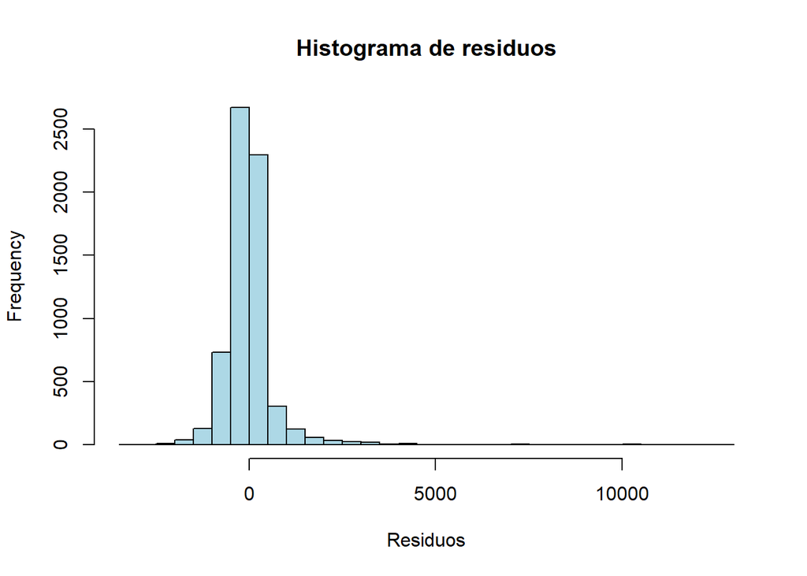

```r
# Obtener residuos y valores ajustados
residuos <- residuals(modelo_Final)
valores_ajustados <- fitted(modelo_Final)

# Histograma de residuos
hist(residuos, breaks = 30, main = "Histograma de residuos", xlab = "Residuos", col = "lightblue")
```

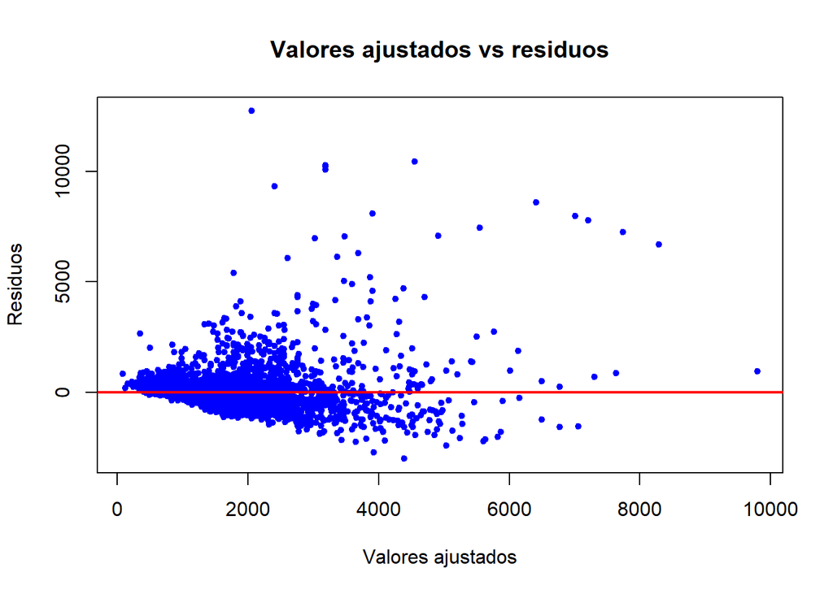

```r
# Gráfico valores ajustados vs residuos
plot(valores_ajustados, residuos,
     main = "Valores ajustados vs residuos",
     xlab = "Valores ajustados",
     ylab = "Residuos",
     pch = 20, col = "blue")
abline(h = 0, col = "red", lwd = 2)
```

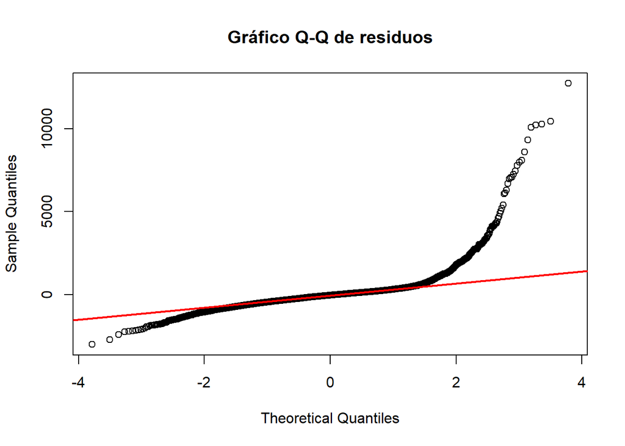

```r
# Gráfico Q-Q para residuos
qqnorm(residuos, main = "Gráfico Q-Q de residuos")
qqline(residuos, col = "red", lwd = 2)
```

En el histograma, al tener valores distribuidos cerca del 0 nos dice que no tiene sesgo sistemático, es decir, ni sobrestima ni subestima de forma consistente

#### 1.7 Predicción del modelo

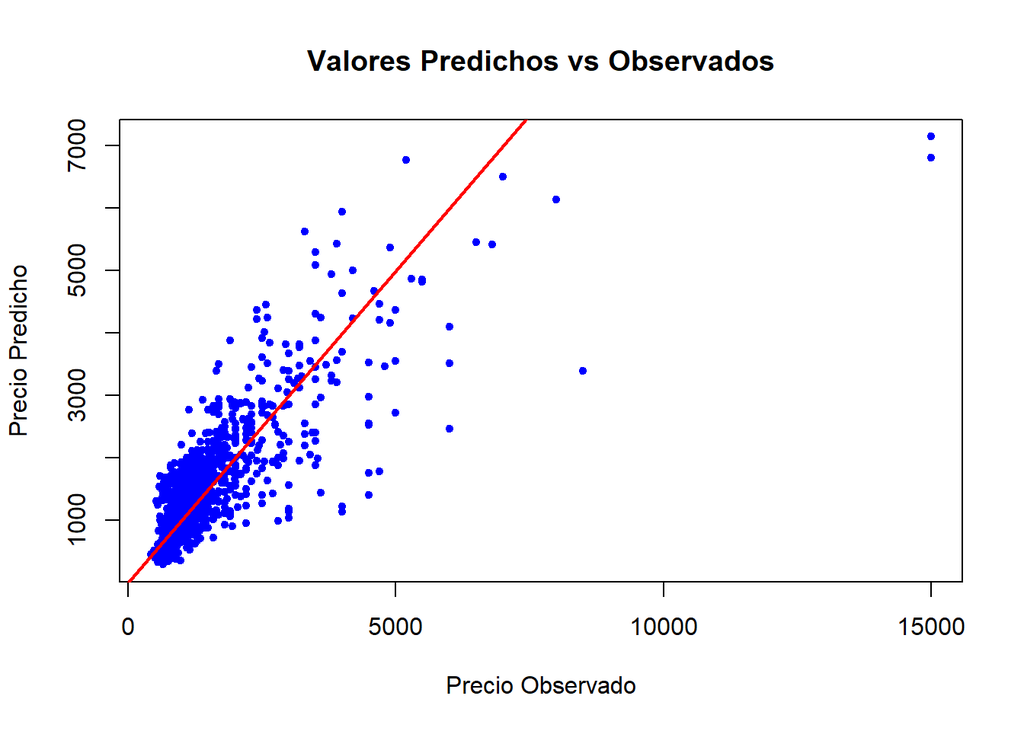

```r
#https://www.digitalocean.com/community/tutorials/predict-function-in-r

predicciones <- predict(modelo_Final, newdata = testing)

# Valores observados reales
observados <- testing$price

# Representar valores predichos vs observados
plot(observados, predicciones,
     xlab = "Precio Observado",
     ylab = "Precio Predicho",
     main = "Valores Predichos vs Observados",
     pch = 20, col = "blue")
abline(a = 0, b = 1, col = "red", lwd = 2)  # Línea de identidad
```

```r
# Calcular RMSE
rmse <- sqrt(mean((observados - predicciones)^2))
rmse
```

```
## [1] 611.7121
```

De media, mis predicciones se alejan 611.7121 euros del valor real, viendo la tabla no parece haber muchas mejores afinaciones por la cantidad de datos en forma de óvalo al principio y por los datos espúreos en el precio observado.

## 2 Regresión logística

#### 2.1 Preparación de los datos

```r
# Precio por metro cuadrado
data$square_meters_price <- data$price / data$square_meters

# Variable dicotómica
data$square_meters_price_re <- ifelse(data$square_meters_price < 20, 0, 1)
```

Más adelante nos piden tomar valores de referencia en los factor, ya que debemos dividir el modelo igual que en el primer apartado, vamos a hacer el relevel antes de partirlo.

```r
data$neighborhood <- relevel(data$neighborhood, ref = "Ciutat Vella")
data$real_state <- relevel(data$real_state, ref = "flat")
```

Dividimos el modelo, 80% datos de training y 20% datos de test

```r
# Semilla aleatoria, se puede cambiar para que sea diferente a la anterior si se desea
set.seed(3461)

split_2 <- sample.split(data$price, SplitRatio = 0.8)
training_2 <- subset(data, split_2 == TRUE)
testing_2 <- subset(data, split_2 == FALSE)
```

#### 2.2 Estimación del modelo de regresión logística con el conjunto de entrenamiento

Igual que en el primer apartado, nos piden realizar el modelo en base a la variable creada anteriormente del precio del metro cuadrado < o > a 20€ y explicar si, para evitar problemas de colinealidad, eliminariamos algun factor del modelo.

```r
modelo_log <- glm(square_meters_price_re ~ neighborhood + real_state + rooms +
                    bathroom +lift + terrace,
                  data = training_2,
                  family = binomial(link = "logit"))
summary(modelo_log)
```

```
##
## Call:
## glm(formula = square_meters_price_re ~ neighborhood + real_state +
##     rooms + bathroom + lift + terrace, family = binomial(link = "logit"),
##     data = training_2)
##
## Coefficients:
##                                  Estimate Std. Error z value Pr(>|z|)
## (Intercept)                      -0.67448    0.10752  -6.273 3.54e-10 ***
## neighborhoodEixample              0.28468    0.09999   2.847 0.004413 **
## neighborhoodGracia               -0.25134    0.14483  -1.735 0.082670 .
## neighborhoodHorta- Guinardo      -1.56292    0.29368  -5.322 1.03e-07 ***
## neighborhoodLes Corts            -0.69495    0.18413  -3.774 0.000160 ***
## neighborhoodNou Barris          -14.81225  246.16184  -0.060 0.952018
## neighborhoodSant Andreu          -1.64880    0.45654  -3.612 0.000304 ***
## neighborhoodSant Martí            0.36869    0.14174   2.601 0.009291 **
## neighborhoodSants-Montjuic       -0.48895    0.16199  -3.018 0.002541 **
## neighborhoodSarria-Sant Gervasi   0.04232    0.11745   0.360 0.718599
## real_stateapartment               2.24343    0.09141  24.542  < 2e-16 ***
## real_stateattic                   1.16435    0.14847   7.842 4.43e-15 ***
## real_statestudy                   0.86767    0.22904   3.788 0.000152 ***
## rooms                            -0.75914    0.04310 -17.614  < 2e-16 ***
## bathroom                          0.62409    0.06039  10.334  < 2e-16 ***
## liftTRUE                         -0.35679    0.07965  -4.480 7.47e-06 ***
## terraceTRUE                       0.25047    0.09041   2.770 0.005601 **
## ---
## Signif. codes:  0 '***' 0.001 '**' 0.01 '*' 0.05 '.' 0.1 ' ' 1
##
## (Dispersion parameter for binomial family taken to be 1)
##
##     Null deviance: 7078.7  on 6479  degrees of freedom
## Residual deviance: 5445.3  on 6463  degrees of freedom
## AIC: 5479.3
##
## Number of Fisher Scoring iterations: 15
```

A simple vista, debemos tener en cuenta aquellos valores con un p-valor mayores a 0.05 o muy cercanos, ya que estos son medidas que explican mal el modelo, así tendríamos a neighborhoodSarria-Sant Gervasi, neighborhoodNou Barris y neighborhoodGracia.

Mirando también los valores del VIF vemos lo siguiente.

```r
vif(modelo_log)
```

```
##                  GVIF Df GVIF^(1/(2*Df))
## neighborhood 1.263384  9        1.013073
## real_state   1.316125  3        1.046846
## rooms        1.803188  1        1.342828
## bathroom     1.757390  1        1.325666
## lift         1.256244  1        1.120823
## terrace      1.190448  1        1.091076
```

Aparentemente no hay ningún atributo con problemas de multi-colinealidad

#### 2.3 Cálculo de las OR (Odss-Ratio)

Las odds ratios indican cuánto se multiplican las probabilidades de que el precio por metro cuadrado sea mayor o igual a 20 €, en comparación con las categorías de referencia, Ciutat Vella y flat. Para calcularlo simplemente es necesario la exponencial de los coeficientes del modelo.

```r
# Calcular Odds Ratios
exp(coef(modelo_log))
```

```
##                     (Intercept)            neighborhoodEixample
##                    5.094227e-01                    1.329337e+00
##              neighborhoodGracia     neighborhoodHorta- Guinardo
##                    7.777554e-01                    2.095227e-01
##           neighborhoodLes Corts          neighborhoodNou Barris
##                    4.990971e-01                    3.690792e-07
##         neighborhoodSant Andreu          neighborhoodSant Martí
##                    1.922804e-01                    1.445834e+00
##      neighborhoodSants-Montjuic neighborhoodSarria-Sant Gervasi
##                    6.132676e-01                    1.043228e+00
##             real_stateapartment                 real_stateattic
##                    9.425619e+00                    3.203853e+00
##                 real_statestudy                           rooms
##                    2.381362e+00                    4.680692e-01
##                        bathroom                        liftTRUE
##                    1.866554e+00                    6.999165e-01
##                     terraceTRUE
##                    1.284623e+00
```

```r
# Intervalos de confianza para las OR
#exp(confint(modelo_log))
```

Los factores de riesgo son aquellos cuyo resultado es > 1 y significa que el suceso es más probable en presencia de dicha covariable

En cambio un factor de protección es lo contrario, se da cuando OR < 1 y significa que el suceso es menos probable en presencia de dicha covariable.

Así podemos considerar los siguientes factores de riesgo y protección.

[output not shown]

[output not shown]

#### 2.4 Matriz de confusión

Una matriz de confusión se crea a partir del siguiente esquema

|  | Valor Real 0 | Valor Real 1 |
| --- | --- | --- |
| Valor Predicho 0 | Verdadero Negativo | Error tipo II, Falso Negativo |
| Valor Predicho 1 | Error tipo I, Falso Positivo | Verdadero Positivo |

Siendo esta una herramienta sencilla para comprobar los errores y aciertos del modelo y a partir de esos valor sacar otras métricas como sensibilidad o especificidad.

Para crear el código de la matriz de confusión me he basado en la explicación del siguiente [enlace](https://keepcoding.io/blog/matriz-de-confusion-en-r/).

```r
# Obtener probabilidades predichas
probabilidades <- predict(modelo_log, newdata = testing_2, type = "response")

# Convertir a predicciones binarias usando umbral 0.5
predicciones <- ifelse(probabilidades < 0.5, 0, 1)

# Crear la matriz de confusión
tabla_confusion <- table(Predicho = predicciones, Real = testing_2$square_meters_price_re)
print(tabla_confusion)
```

```
##         Real
## Predicho    0    1
##        0 1109  208
##        1   62   90
```

```r
# Calcular sensibilidad y especificidad
TP <- tabla_confusion["1", "1"]  # Verdaderos positivos
TN <- tabla_confusion["0", "0"]  # Verdaderos negativos
FP <- tabla_confusion["1", "0"]  # Falsos positivos
FN <- tabla_confusion["0", "1"]  # Falsos negativos

sensibilidad <- TP / (TP + FN)
especificidad <- TN / (TN + FP)

cat("Sensibilidad:", sensibilidad, "\n")
```

```
## Sensibilidad: 0.3020134
```

```r
cat("Especificidad:", especificidad, "\n")
```

```
## Especificidad: 0.9470538
```

Después de calcular la matriz, su sensibilidad y especifidad podemos sacar las siguientes conclusiones.

La especificidad es la más alta de las dos métricas obtenidas. Esta sirve para ver la proporción de casos correctamente clasificados entre las respuestas negativas. Para ello tenemos que ver todas las respuestas negativa un total de 1171(TN + FP) y ver cuantas ha predicho nuestro modelo correctamente, en nuestro caso un total de 1109.

Esto nos dice que tenemos un modelo que acierta más en los casos negativos que positivos, un modelo pesimista donde podemos intentar mejorar en el aspecto de los postivos.

#### 2.5 Predicción

```r
# Usamos las predicciones que hemos sacado en el apartado anterior
testing_2$pred_class <- predicciones

# Hacemos un subconjunto solo con las viviendas más caras
viviendas_caras <- subset(testing_2, pred_class == 1)

# Muestra en tabla los barrios y tipos de vivienda de esas viviendas caras
tabla_viviendas_caras <- table(viviendas_caras$neighborhood, viviendas_caras$real_state)

# Mostrar tabla
print(tabla_viviendas_caras)
```

```
##
##                       flat apartment attic study
##   Ciutat Vella           1        37     6     5
##   Eixample               2        45     6     1
##   Gracia                 0         5     2     1
##   Horta- Guinardo        0         0     0     0
##   Les Corts              0         2     0     0
##   Nou Barris             0         0     0     0
##   Sant Andreu            0         0     0     0
##   Sant Martí             0         8     0     2
##   Sants-Montjuic         0         2     1     1
##   Sarria-Sant Gervasi    0        21     2     2
```

Podemos ver que los apartamentos suelen ser los que más cumplen esta condicion del precio del metro cuadrado, además de los barrios de Ciutat Vella, Eixampie y Sarria como deciamos en el primer apartado

#### 2.6 Bondad del ajuste y curva ROC

En este apartado nos piden evaluar la eficacia del modelo según el test Chi-cuadrado. Donde, en este caso el valor del estadístico Chi-cuadrado observado es igual a la diferencia de devianzas (nula-residual). Estos valores ya podemos sacarlos del modelo

```r
# Estadístico chi-cuadrado
chi2 <- modelo_log$null.deviance - modelo_log$deviance

# Grados de libertad
gl <- modelo_log$df.null - modelo_log$df.residual
#p -valor
p_value <- 1 - pchisq(chi2, df = gl)

cat("Chi-cuadrado:", chi2, "\n")
```

```
## Chi-cuadrado: 1633.383
```

```r
cat("p-valor:", p_value, "\n")
```

```
## p-valor: 0
```

```r
roc_obj <- roc(testing_2$square_meters_price_re, probabilidades)
```

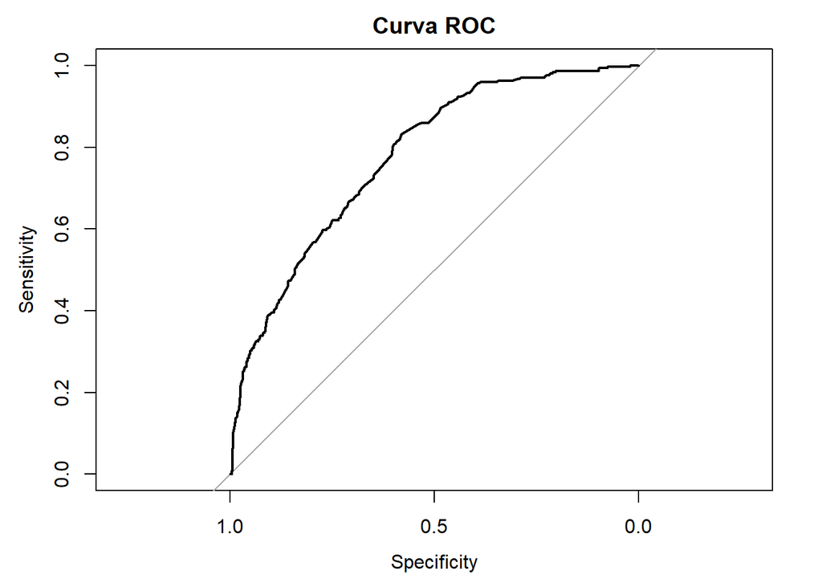

```r
# Curva ROC
plot(roc_obj, main = "Curva ROC")
```

```r
# Área bajo la curva (AUC)
cat("Área bajo la curva (AUC):", auc(roc_obj), "\n")
```

```
## Área bajo la curva (AUC): 0.7760447
```

El valor obtenido del área debajo de la curva ROC es de 0.776, por lo general tenemos que este es un modelo que discrimina de manera adecuada. Es decir, tiene buena capacidad de distinguir entre clases, 1 o 0 en nuestro caso del precio del metro cuadrado. Cuanto mayor es el área mayor discrimina el modelo.

#### 2.7 Modelo de regresión logística multinomial

Para calcular la regresión logística multinominal he usado la función [multinom](https://stats.oarc.ucla.edu/r/dae/multinomial-logistic-regression/) de R

```r
# Ajustar el modelo multinomial usando training_2
modelo_multi <- multinom(real_state ~ price + rooms + bathroom + square_meters, data = training_2)
# Predecir las categorías en testing_2
predicciones <- predict(modelo_multi, newdata = testing_2)
# Crear matriz de confusión
confusion <- table(Predicted = predicciones, Actual = testing_2$real_state)
print(confusion)
```

```
##            Actual
## Predicted   flat apartment attic study
##   flat      1232       121    51    20
##   apartment   14        12     1     0
##   attic        1         0     1     0
##   study        5         4     1     6
```

```r
precision <- sum(diag(confusion)) / sum(confusion)
cat("Precisión del modelo multinomial:", precision, "\n")
```

```
## Precisión del modelo multinomial: 0.8515997
```

Acertó el tipo de vivienda en el 85% de los casos del conjunto de test. Aunque parece alto, hay que tener cuidado. Si un atributo es muy abundante, flat por ejemplo que vemos que hay muchas más en comparación al resto, el modelo puede obtener buena precisión simplemente prediciendo siempre ese atributo.

## 3 Resumen ejecutivo. Conclusiones del análisis

[output not shown]